# Ugly Selfies Experiment Analysis

Ruth Page (principal investigator), Bodo Winter (analysis)

6/11/2018

## Introduction

In this file, the Qualtrics data will be analyzed. It requires the “selfies_cleaned.csv” file that is produced by the “preprocessing.Rmd” Markdown script. The analysis is separated into the following stages:

- analysis of correlations between hashtags
- analysis of condition effects onto hashtag ratings
- analysis of individual differences in condition effects

```r
library(stringr)
library(lme4)
library(afex)
library(brms)
library(MuMIn)
library(tidyverse)
library(factoextra)
library(gridExtra)

# load ggplot theme:
source('theme_timo.R')

# load data:
self <- read_csv('data/selfies_cleaned.csv')
self
```

```
## # A tibble: 2,154 x 16
##    ResponseId       Dur   Age Country Gender Socialmedia Selfietaking
##    <chr>          <int> <int> <chr>   <chr>  <chr>       <chr>
##  1 R_00OlMTXsIar…  1732    34 usa     Male   <NA>        Less than once a…
##  2 R_00OlMTXsIar…  1732    34 usa     Male   <NA>        Less than once a…
##  3 R_00OlMTXsIar…  1732    34 usa     Male   <NA>        Less than once a…
##  4 R_00OlMTXsIar…  1732    34 usa     Male   <NA>        Less than once a…
##  5 R_00OlMTXsIar…  1732    34 usa     Male   <NA>        Less than once a…
##  6 R_00OlMTXsIar…  1732    34 usa     Male   <NA>        Less than once a…
##  7 R_00OlMTXsIar…  1732    34 usa     Male   <NA>        Less than once a…
##  8 R_00OlMTXsIar…  1732    34 usa     Male   <NA>        Less than once a…
##  9 R_00OlMTXsIar…  1732    34 usa     Male   <NA>        Less than once a…
## 10 R_00OlMTXsIar…  1732    34 usa     Male   <NA>        Less than once a…
## # ... with 2,144 more rows, and 9 more variables: StimGender <chr>,
## #   Tilt <chr>, Distance <chr>, Eyes <chr>, Boring <int>, Funny <int>,
## #   Ironic <int>, Serious <int>, Ugly <int>
```

Through these and the analyses below, we want to have unique item identifiers. Since the entire design is between-items, these item identifiers can be created by pasting all the condition columns together.

```r
self <- mutate(self,
               ItemID = str_c(StimGender, ':', Tilt, ':', Distance, ':', Eyes))
length(unique(self$ItemID))
```

```
## [1] 16
```

There were 16 unique items.

Let’s check the basic stats for participants (also what is reported in the paper):

```r
# Participants:
length(unique(self$ResponseId))
```

```
## [1] 135
```

```r
# Participant age range:
ppt_demo <- filter(self, !duplicated(ResponseId))
range(ppt_demo$Age)
```

```
## [1] 18 65
```

```r
# Participant mean and sd age:
mean(ppt_demo$Age); sd(ppt_demo$Age)
```

```
## [1] 31.32593
```

```
## [1] 10.61387
```

```r
# How many per decade?
table(cut(ppt_demo$Age, breaks = seq(10, 70, 10)))
```

```
##
## (10,20] (20,30] (30,40] (40,50] (50,60] (60,70]
##      21      49      43      14       4       4
```

```r
prop.table(table(cut(ppt_demo$Age, breaks = seq(10, 70, 10))))
```

```
##
##    (10,20]    (20,30]    (30,40]    (40,50]    (50,60]    (60,70]
## 0.15555556 0.36296296 0.31851852 0.10370370 0.02962963 0.02962963
```

```r
# Gender?
table(ppt_demo$Gender)
```

```
##
## Female   Male
##     63     72
```

```r
prop.table(table(ppt_demo$Gender))
```

```
##
##    Female      Male
## 0.4666667 0.5333333
```

```r
# Total data points:
nrow(self)
```

```
## [1] 2154
```

## Analysis 1: Correlations between hashtags

We are interested whether across items, ugliness ratings are correlated with funniness ratings etc. For this, we can compute item-based averages (we are ignoring by-subject variation in this specific analysis).

```r
byitem_avg <- self %>% group_by(ItemID) %>%
  summarize(Boring = mean(Boring, na.rm = TRUE),
            Funny = mean(Funny, na.rm = TRUE),
            Ironic = mean(Ironic, na.rm = TRUE),
            Serious = mean(Serious, na.rm = TRUE),
            Ugly = mean(Ugly, na.rm = TRUE))
cor_matrix <- cor(select(byitem_avg, -ItemID), use = 'pairwise.complete')
round(cor_matrix, 2)
```

```
##         Boring Funny Ironic Serious  Ugly
## Boring    1.00 -0.76  -0.05    0.81 -0.28
## Funny    -0.76  1.00   0.42   -0.92  0.75
## Ironic   -0.05  0.42   1.00   -0.20  0.35
## Serious   0.81 -0.92  -0.20    1.00 -0.63
## Ugly     -0.28  0.75   0.35   -0.63  1.00
```

These are Pearson’s correlation coefficients. There are high positive correlations between seriousness and borigness ratings (r = 0.81) and between ugliness and funniness ratings (r = 0.75). There are strong negative correlations between funniness and boringness (r = -0.76), and between funniness and seriousness (r = -0.92).

We can perform item-wise significance tests of these correlations.

```r
attach(byitem_avg)
cor.test(Boring, Funny) # anti-correlated
```

```
##
##  Pearson's product-moment correlation
##
## data:  Boring and Funny
## t = -4.4367, df = 14, p-value = 0.0005636
## alternative hypothesis: true correlation is not equal to 0
## 95 percent confidence interval:
##  -0.9138546 -0.4327102
## sample estimates:
##        cor
## -0.7644446
```

```r
cor.test(Boring, Ironic)
```

```
##
##  Pearson's product-moment correlation
##
## data:  Boring and Ironic
## t = -0.18477, df = 14, p-value = 0.8561
## alternative hypothesis: true correlation is not equal to 0
## 95 percent confidence interval:
##  -0.5320198  0.4575706
## sample estimates:
##         cor
## -0.04932195
```

```r
cor.test(Boring, Serious)   # correlated
```

```
##
##  Pearson's product-moment correlation
##
## data:  Boring and Serious
## t = 5.2061, df = 14, p-value = 0.0001331
## alternative hypothesis: true correlation is not equal to 0
## 95 percent confidence interval:
##  0.5294465 0.9324148
## sample estimates:
##      cor
## 0.812034
```

```r
cor.test(Boring, Ugly)
```

```
##
##  Pearson's product-moment correlation
##
## data:  Boring and Ugly
## t = -1.1066, df = 14, p-value = 0.2871
## alternative hypothesis: true correlation is not equal to 0
## 95 percent confidence interval:
##  -0.6832584  0.2467904
## sample estimates:
##        cor
## -0.2836105
```

```r
cor.test(Funny, Ironic)
```

```
##
##  Pearson's product-moment correlation
##
## data:  Funny and Ironic
## t = 1.7118, df = 14, p-value = 0.109
## alternative hypothesis: true correlation is not equal to 0
## 95 percent confidence interval:
##  -0.1003865  0.7558517
## sample estimates:
##       cor
## 0.4160209
```

```r
cor.test(Funny, Serious)    # anti-correlated
```

```
##
##  Pearson's product-moment correlation
##
## data:  Funny and Serious
## t = -9.0092, df = 14, p-value = 3.347e-07
## alternative hypothesis: true correlation is not equal to 0
## 95 percent confidence interval:
##  -0.9735428 -0.7890224
## sample estimates:
##        cor
## -0.9235187
```

```r
cor.test(Funny, Ugly)   # correlated
```

```
##
##  Pearson's product-moment correlation
##
## data:  Funny and Ugly
## t = 4.2327, df = 14, p-value = 0.0008357
## alternative hypothesis: true correlation is not equal to 0
## 95 percent confidence interval:
##  0.4033167 0.9077865
## sample estimates:
##       cor
## 0.7492311
```

```r
cor.test(Ironic, Serious)
```

```
##
##  Pearson's product-moment correlation
##
## data:  Ironic and Serious
## t = -0.76218, df = 14, p-value = 0.4586
## alternative hypothesis: true correlation is not equal to 0
## 95 percent confidence interval:
##  -0.6327046  0.3286187
## sample estimates:
##        cor
## -0.1996013
```

```r
cor.test(Ironic, Ugly)
```

```
##
##  Pearson's product-moment correlation
##
## data:  Ironic and Ugly
## t = 1.3933, df = 14, p-value = 0.1853
## alternative hypothesis: true correlation is not equal to 0
## 95 percent confidence interval:
##  -0.1774335  0.7201039
## sample estimates:
##       cor
## 0.3489649
```

```r
cor.test(Serious, Ugly) # anti-correlated
```

```
##
##  Pearson's product-moment correlation
##
## data:  Serious and Ugly
## t = -3.0698, df = 14, p-value = 0.008316
## alternative hypothesis: true correlation is not equal to 0
## 95 percent confidence interval:
##  -0.8596878 -0.2021322
## sample estimates:
##        cor
## -0.6342836
```

```r
detach(byitem_avg)
```

We are performing multiple comparisons here, thus inflating our family-wise Type I error rate. It would be important to know that the results are substantively the same if we correct for performing 10 significance tests.

```r
attach(byitem_avg)
p.adjust(cor.test(Boring, Funny)$p.value, n = 10, method = 'bonferroni')
```

```
## [1] 0.005636145
```

```r
p.adjust(cor.test(Boring, Ironic)$p.value, n = 10, method = 'bonferroni')
```

```
## [1] 1
```

```r
p.adjust(cor.test(Boring, Serious)$p.value, n = 10, method = 'bonferroni')
```

```
## [1] 0.001330848
```

```r
p.adjust(cor.test(Boring, Ugly)$p.value, n = 10, method = 'bonferroni')
```

```
## [1] 1
```

```r
p.adjust(cor.test(Funny, Ironic)$p.value, n = 10, method = 'bonferroni')
```

```
## [1] 1
```

```r
p.adjust(cor.test(Funny, Serious)$p.value, n = 10, method = 'bonferroni')
```

```
## [1] 3.347085e-06
```

```r
p.adjust(cor.test(Funny, Ugly)$p.value, n = 10, method = 'bonferroni')
```

```
## [1] 0.008357023
```

```r
p.adjust(cor.test(Ironic, Serious)$p.value, n = 10, method = 'bonferroni')
```

```
## [1] 1
```

```r
p.adjust(cor.test(Ironic, Ugly)$p.value, n = 10, method = 'bonferroni')
```

```
## [1] 1
```

```r
p.adjust(cor.test(Serious, Ugly)$p.value, n = 10, method = 'bonferroni')
```

```
## [1] 0.08316296
```

```r
detach(byitem_avg)
```

Most of the p-values that were significant before are still significant after correction. The only result for which there is a change in substantive conclusion after correction is between seriousness and ugliness ratings, which is then not significant anymore (p = 0.08). The corrected p-values will be reported in the paper.

Let’s make a plot of the variables that correlate:

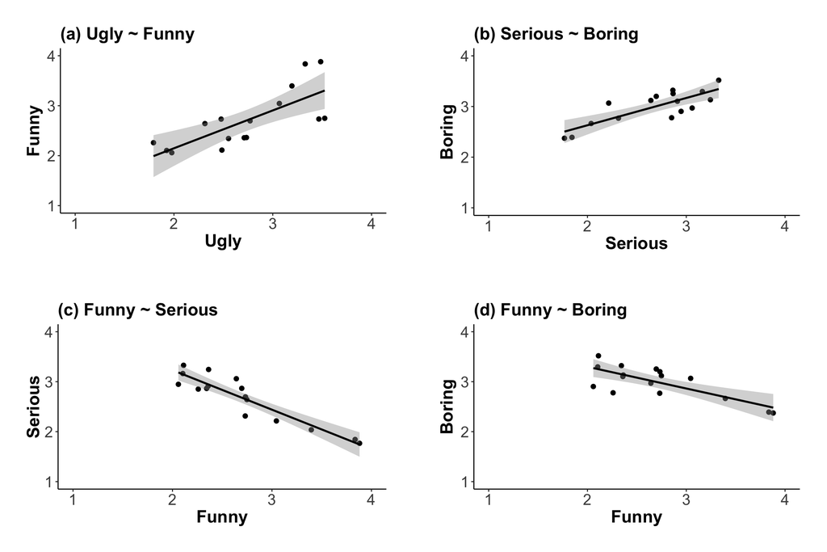

```r
p1 <- ggplot(byitem_avg, aes(x = Ugly, y = Funny)) +
  geom_point(size = 2) +
  geom_smooth(method = 'lm', color = 'black') +
  theme_timo + xlim(1, 4) + ylim(1, 4) +
  ggtitle('(a) Ugly ~ Funny')
p2 <- ggplot(byitem_avg, aes(x = Serious, y = Boring)) +
  geom_point(size = 2) +
  geom_smooth(method = 'lm', color = 'black') +
  theme_timo + xlim(1, 4) + ylim(1, 4) +
  ggtitle('(b) Serious ~ Boring')
p3 <- ggplot(byitem_avg, aes(x = Funny, y = Serious)) +
  geom_point(size = 2) +
  geom_smooth(method = 'lm', color = 'black') +
  theme_timo + xlim(1, 4) + ylim(1, 4) +
  ggtitle('(c) Funny ~ Serious')
p4 <- ggplot(byitem_avg, aes(x = Funny, y = Boring)) +
  geom_point(size = 2) +
  geom_smooth(method = 'lm', color = 'black') +
  theme_timo + xlim(1, 4) + ylim(1, 4) +
  ggtitle('(d) Funny ~ Boring')
# create plot matrix
grid.arrange(p1, p2, p3, p4, nrow = 2)
```

We can perform a PCA to further explore by-item differences further.

```r
self_pca <- prcomp(byitem_avg[, -1], center = TRUE, scale = TRUE)
```

Let’s have a look at a scree plot to see how much each dimension contributes:

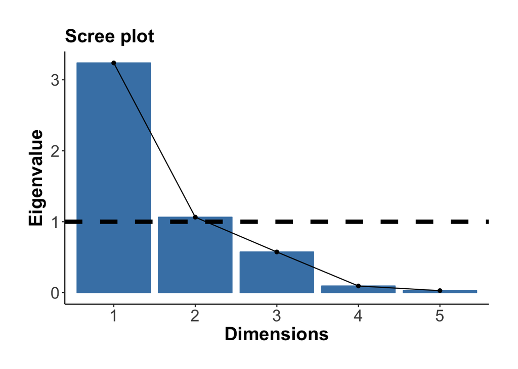

```r
fviz_screeplot(self_pca, choice = 'eigenvalue') +
  geom_hline(yintercept = 1.0, linetype = 2, size = 2) + theme_timo
```

This scree plot suggests that at maximum, there should be two dimensions, if not only one (the second dimension barely passes the criteria for Kaiser’s rule that eigenvalues should be > 1).

Let’s create a variable coordinate plot for the first two dimensions:

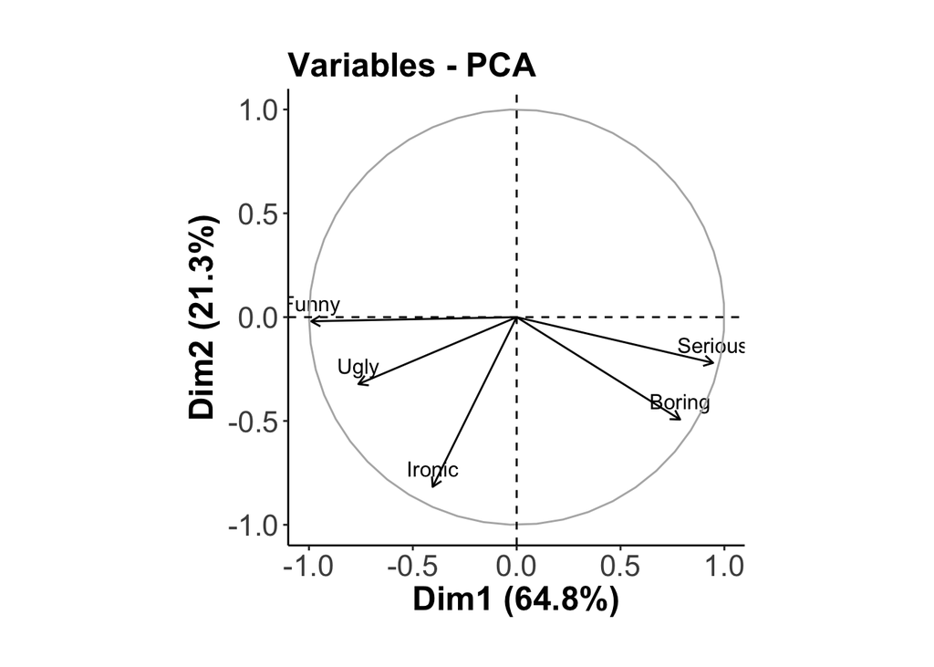

```r
fviz_pca_var(self_pca) + theme_timo
```

Let’s have a look at the loadings for each dimension:

```r
round(self_pca$rotation, 2)
```

```
##           PC1   PC2   PC3   PC4   PC5
## Boring   0.44 -0.48  0.43  0.56  0.28
## Funny   -0.55 -0.02 -0.01  0.00  0.83
## Ironic  -0.22 -0.79 -0.54  0.00 -0.17
## Serious  0.53 -0.21 -0.02 -0.75  0.34
## Ugly    -0.42 -0.31  0.72 -0.35 -0.27
```

Let’s extract the scores for each word.

```r
self_scores <- as.data.frame(self_pca$x)
self_scores$Condition <- byitem_avg$ItemID
self_scores <- separate(self_scores,
                        Condition, into = c('StimGender', 'Tilt', 'Distance', 'Eyes'))
```

Let’s make a plot of this:

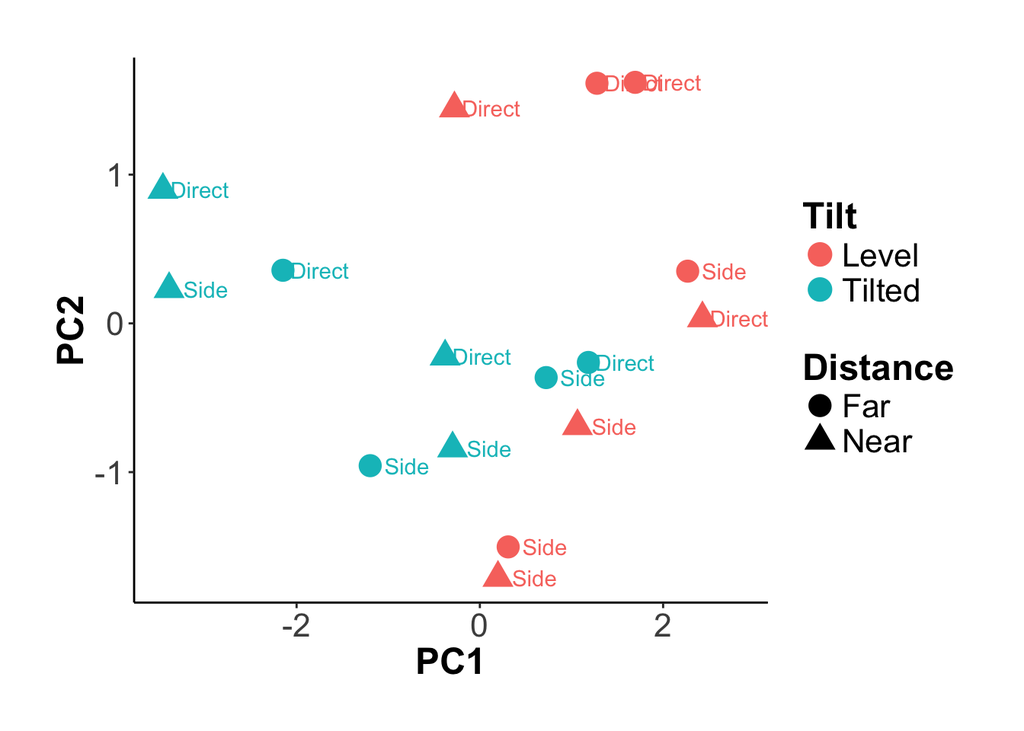

```r
self_scores %>% ggplot(aes(x = PC1, y = PC2, col = Tilt, shape = Distance)) + geom_point(size = 5) + geom_text(aes(x = PC1 + 0.4, y = PC2, label = Eyes)) + theme_timo
```

## Analysis 2: Test of condition effects

In this section, we will use linear mixed effects models to test the condition effects. We will build separate models for each rating scale. We will fit a linear mixed effects model in which the rating scale is the main dependent variable. In each model, the dependent variable is regressed onto the four condition variables (fixed effects, no interactions). As random effects, we have random intercepts for subjects and items. For items, we do not need any random slopes since conditions do not vary within items. For subjects, we will add random slopes for each of the fixed effects. The random effects structure includes correlations between random slopes.

The main analysis is Bayesian, using the brms package. However, to easily compute R-squared values, frequentist linear mixed effects models were fitted as well. For this, we use the mixed() function from the afex package to fit these models, which fits models with REML = FALSE (Maximum Likelihood) and computes p-values based on likelihood ratio tests comparing the models with the fixed effect in question against the model without the fixed effect in question.

```r
print(boring.afex <- mixed(Boring ~ 1 +
                             Tilt + Distance + Eyes + StimGender +
                              (1 + Tilt + Distance + Eyes + StimGender|ResponseId) + (1|ItemID),
                           data = self, method = 'LRT'))
```

```
## Fitting 5 (g)lmer() models:
## [.....]
## Mixed Model Anova Table (Type 3 tests, LRT-method)
##
## Model: Boring ~ 1 + Tilt + Distance + Eyes + StimGender + (1 + Tilt +
## Model:     Distance + Eyes + StimGender | ResponseId) + (1 | ItemID)
## Data: self
## Df full model: 22
##       Effect df   Chisq p.value
## 1       Tilt  1  3.14 +     .08
## 2   Distance  1    0.01     .94
## 3       Eyes  1    2.25     .13
## 4 StimGender  1 8.68 **    .003
## ---
## Signif. codes:  0 '***' 0.001 '**' 0.01 '*' 0.05 '+' 0.1 ' ' 1
```

```r
print(funny.afex <- mixed(Funny ~ 1 +
                            Tilt + Distance + Eyes + StimGender +
                              (1 + Tilt + Distance + Eyes + StimGender|ResponseId) + (1|ItemID),
                          data = self, method = 'LRT'))
```

```
## Fitting 5 (g)lmer() models:
## [.....]
## Mixed Model Anova Table (Type 3 tests, LRT-method)
##
## Model: Funny ~ 1 + Tilt + Distance + Eyes + StimGender + (1 + Tilt +
## Model:     Distance + Eyes + StimGender | ResponseId) + (1 | ItemID)
## Data: self
## Df full model: 22
##       Effect df     Chisq p.value
## 1       Tilt  1 16.68 ***  <.0001
## 2   Distance  1   6.84 **    .009
## 3       Eyes  1      0.05     .83
## 4 StimGender  1 16.25 ***  <.0001
## ---
## Signif. codes:  0 '***' 0.001 '**' 0.01 '*' 0.05 '+' 0.1 ' ' 1
```

```r
print(ironic.afex <- mixed(Ironic ~ 1 +
                             Tilt + Distance + Eyes + StimGender +
                              (1 + Tilt + Distance + Eyes + StimGender|ResponseId) + (1|ItemID),
                           data = self, method = 'LRT'))
```

```
## Fitting 5 (g)lmer() models:
## [.....]
## Mixed Model Anova Table (Type 3 tests, LRT-method)
##
## Model: Ironic ~ 1 + Tilt + Distance + Eyes + StimGender + (1 + Tilt +
## Model:     Distance + Eyes + StimGender | ResponseId) + (1 | ItemID)
## Data: self
## Df full model: 22
##       Effect df     Chisq p.value
## 1       Tilt  1    4.31 *     .04
## 2   Distance  1      0.02     .90
## 3       Eyes  1 12.42 ***   .0004
## 4 StimGender  1    4.63 *     .03
## ---
## Signif. codes:  0 '***' 0.001 '**' 0.01 '*' 0.05 '+' 0.1 ' ' 1
```

```r
print(serious.afex <- mixed(Serious ~ 1 +
                              Tilt + Distance + Eyes + StimGender +
                              (1 + Tilt + Distance + Eyes + StimGender|ResponseId) + (1|ItemID),
                            data = self, method = 'LRT'))
```

```
## Fitting 5 (g)lmer() models:
## [.....]
## Mixed Model Anova Table (Type 3 tests, LRT-method)
##
## Model: Serious ~ 1 + Tilt + Distance + Eyes + StimGender + (1 + Tilt +
## Model:     Distance + Eyes + StimGender | ResponseId) + (1 | ItemID)
## Data: self
## Df full model: 22
##       Effect df     Chisq p.value
## 1       Tilt  1  10.57 **    .001
## 2   Distance  1    3.71 +     .05
## 3       Eyes  1      0.00    >.99
## 4 StimGender  1 13.11 ***   .0003
## ---
## Signif. codes:  0 '***' 0.001 '**' 0.01 '*' 0.05 '+' 0.1 ' ' 1
```

```r
print(ugly.afex <- mixed(Ugly ~ 1 +
                           Tilt + Distance + Eyes + StimGender +
                              (1 + Tilt + Distance + Eyes + StimGender|ResponseId) + (1|ItemID),
                         data = self, method = 'LRT'))
```

```
## Fitting 5 (g)lmer() models:
## [.....]
## Mixed Model Anova Table (Type 3 tests, LRT-method)
##
## Model: Ugly ~ 1 + Tilt + Distance + Eyes + StimGender + (1 + Tilt +
## Model:     Distance + Eyes + StimGender | ResponseId) + (1 | ItemID)
## Data: self
## Df full model: 22
##       Effect df     Chisq p.value
## 1       Tilt  1 37.84 ***  <.0001
## 2   Distance  1 24.88 ***  <.0001
## 3       Eyes  1      0.71     .40
## 4 StimGender  1    3.89 *     .05
## ---
## Signif. codes:  0 '***' 0.001 '**' 0.01 '*' 0.05 '+' 0.1 ' ' 1
```

There are convergence issues for the Ironic and the Serious models.

We can use R-squared (marginal R-squared for fixed effects, following Nakagawa & Schielzeth, 2013) to assess how good the predictors explain variation for each of the rating scales.

```r
# Extract first
print(boring.rsq <- r.squaredGLMM(boring.afex$full_model))
```

```
##        R2m        R2c
## 0.03451368 0.51117932
```

```r
print(funny.rsq <- r.squaredGLMM(funny.afex$full_model))
```

```
##       R2m       R2c
## 0.1540938 0.5694202
```

```r
print(ironic.rsq <- r.squaredGLMM(ironic.afex$full_model))
```

```
##        R2m        R2c
## 0.01878193 0.51299340
```

```r
print(serious.rsq <- r.squaredGLMM(serious.afex$full_model))
```

```
##       R2m       R2c
## 0.1037599 0.4422546
```

```r
print(ugly.rsq <- r.squaredGLMM(ugly.afex$full_model))
```

```
##       R2m       R2c
## 0.1709147 0.6651435
```

Higher values correspond to more variance described. Together, the four predictors are best at accounting for variation in responses for ugliness ratings (17% of the variation) and funniness ratings (15%). The four predictors account for only 10% variation in seriousness ratings. Finally, for boring and ironic ratings, the described variation is quite marginal, with only 3% and 2% respectively. This suggests that the condition “don’t do much” for boring and ironic ratings, compared to ugly and funny ratings.

It seems that the R-square values might correspond to frequency with which the corresponding hashtags are observed in the instagram corpus.

```r
# get corpus frequencies:
insta <- read_csv('data/instagram_hashtag_frequency.csv')
# compute cumulative frequencies and their logs:
insta <- insta %>% group_by(type) %>%
  summarize(freq = sum(frequency)) %>%
  mutate(log_freq = log10(freq))
# get the r-squared values (marginal):
insta$rsq <- c(boring.rsq['R2m'],
               funny.rsq['R2m'],
               ironic.rsq['R2m'],
               serious.rsq['R2m'],
               ugly.rsq['R2m'])
# correlate these:
with(insta, cor.test(rsq, log_freq))
```

```
##
##  Pearson's product-moment correlation
##
## data:  rsq and log_freq
## t = 3.9658, df = 3, p-value = 0.02864
## alternative hypothesis: true correlation is not equal to 0
## 95 percent confidence interval:
##  0.1783150 0.9945584
## sample estimates:
##       cor
## 0.9164105
```

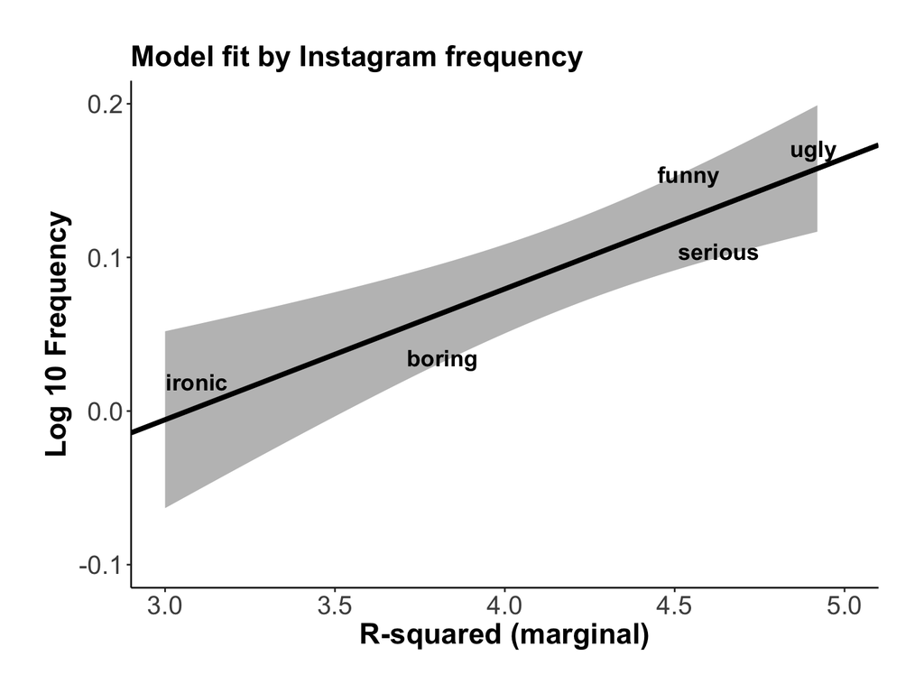

```r
# linear model of this:
freq_mdl <- lm(rsq ~ log_freq, data = insta)
xvals <- seq(3, 5, 0.01)
mypreds <- as.data.frame(predict.lm(freq_mdl,
                         data.frame(log_freq = xvals),
                         se.fit = TRUE)[1:2]) %>%
  mutate(LB = fit - 1.96 * se.fit, UB = fit + 1.96 * se.fit) %>%
  mutate(rsq = fit)
mypreds$xvals <- xvals
# make a plot of this:
ggplot(mypreds) +
  geom_ribbon(fill = rgb(0, 0, 0, 0.3),
              aes(x = xvals, ymin = LB, ymax = UB)) +
  geom_abline(aes(intercept = coef(freq_mdl)[1],
              slope = coef(freq_mdl)[2]), size = 1.5) +
  geom_text(data = insta, aes(x = log_freq, y = rsq, label = type),
            hjust = 0.5, size = 5, fontface = 'bold') +
  xlim(3, 5) + ylim(-0.1, 0.2) + ggtitle('Model fit by Instagram frequency') + xlab('R-squared (marginal)') + ylab('Log 10 Frequency') +
  theme_timo
```

```r
# (actually, this graph doesn't make much sense because the linear model doesn't know that these R-squared values can't go much below 0)
```

Same thing with Bayesian analysis and ordinal regression. We’re going to fit an ordinal logistic regression model. These are fairly agnostic priors.

```r
my_priors <- c(prior(normal(0, 2), class = b))
```

Set cores so that I can compute in parallel (faster).

```r
options(mc.cores=parallel::detectCores())
```

Set controls for MCMC sampling that make it more likely to converge.

```r
my_controls <- list(adapt_delta = 0.99,
                    max_treedepth = 13)
xwarmup <- 2000
xiter <- 4000
```

Run the Bayesian model.

```r
set.seed(42)
boring.brm <- brm(Boring ~ 1 +
                             Tilt + Distance + Eyes + StimGender +
                              (1 + Tilt + Distance + Eyes + StimGender|ResponseId) + (1|ItemID),
                           data = self, prior = my_priors,
                  control = my_controls,
                  warmup = xwarmup, iter = xiter, chains = 4,
                  family = cumulative('logit'))
funny.brm <- brm(Funny ~ 1 +
                             Tilt + Distance + Eyes + StimGender +
                              (1 + Tilt + Distance + Eyes + StimGender|ResponseId) + (1|ItemID),
                           data = self, prior = my_priors,
                  control = my_controls,
                  warmup = xwarmup, iter = xiter, chains = 4,
                  family = cumulative('logit'))
serious.brm <- brm(Serious ~ 1 +
                             Tilt + Distance + Eyes + StimGender +
                              (1 + Tilt + Distance + Eyes + StimGender|ResponseId) + (1|ItemID),
                           data = self, prior = my_priors,
                  control = my_controls,
                  warmup = xwarmup, iter = xiter, chains = 4,
                  family = cumulative('logit'))
ironic.brm <- brm(Ironic ~ 1 +
                             Tilt + Distance + Eyes + StimGender +
                              (1 + Tilt + Distance + Eyes + StimGender|ResponseId) + (1|ItemID),
                           data = self, prior = my_priors,
                  control = my_controls,
                  warmup = xwarmup, iter = xiter, chains = 4,
                  family = cumulative('logit'))
ugly.brm <- brm(Ugly ~ 1 +
                             Tilt + Distance + Eyes + StimGender +
                              (1 + Tilt + Distance + Eyes + StimGender|ResponseId) + (1|ItemID),
                           data = self, prior = my_priors,
                  control = my_controls,
                  warmup = xwarmup, iter = xiter, chains = 4,
                  family = cumulative('logit'))
```

Save these models.

```r
save(boring.brm, file = 'model_files/boring.brm.RData')
save(funny.brm, file = 'model_files/funny.brm.RData')
save(serious.brm, file = 'model_files/serious.brm.RData')
save(ironic.brm, file = 'model_files/ironic.brm.RData')
save(ugly.brm, file = 'model_files/ugly.brm.RData')
```

Load models (if eval = FALSE for the other chunks).

```r
load('model_files/boring.brm.RData')
load('model_files/funny.brm.RData')
load('model_files/serious.brm.RData')
load('model_files/ironic.brm.RData')
load('model_files/ugly.brm.RData')
```

Print the models outputs.

```r
summary(boring.brm)
```

```
##  Family: cumulative
##   Links: mu = logit; disc = identity
## Formula: Boring ~ 1 + Tilt + Distance + Eyes + StimGender + (1 + Tilt + Distance + Eyes + StimGender | ResponseId) + (1 | ItemID)
##    Data: self (Number of observations: 2151)
## Samples: 4 chains, each with iter = 4000; warmup = 2000; thin = 1;
##          total post-warmup samples = 8000
##
## Group-Level Effects:
## ~ItemID (Number of levels: 16)
##               Estimate Est.Error l-95% CI u-95% CI Eff.Sample Rhat
## sd(Intercept)     0.57      0.16     0.35     0.95       3135 1.00
##
## ~ResponseId (Number of levels: 135)
##                                  Estimate Est.Error l-95% CI u-95% CI
## sd(Intercept)                        2.05      0.19     1.69     2.45
## sd(TiltTilted)                       1.45      0.15     1.17     1.75
## sd(DistanceNear)                     0.93      0.15     0.64     1.24
## sd(EyesSide)                         0.81      0.14     0.53     1.08
## sd(StimGenderMale)                   1.21      0.14     0.95     1.50
## cor(Intercept,TiltTilted)           -0.44      0.10    -0.63    -0.23
## cor(Intercept,DistanceNear)         -0.38      0.14    -0.63    -0.09
## cor(TiltTilted,DistanceNear)         0.57      0.13     0.30     0.80
## cor(Intercept,EyesSide)             -0.13      0.16    -0.44     0.20
## cor(TiltTilted,EyesSide)             0.51      0.15     0.19     0.78
## cor(DistanceNear,EyesSide)          -0.04      0.20    -0.42     0.36
## cor(Intercept,StimGenderMale)       -0.06      0.13    -0.31     0.21
## cor(TiltTilted,StimGenderMale)       0.09      0.14    -0.19     0.36
## cor(DistanceNear,StimGenderMale)    -0.22      0.16    -0.53     0.11
## cor(EyesSide,StimGenderMale)        -0.06      0.18    -0.40     0.29
##                                  Eff.Sample Rhat
## sd(Intercept)                          3211 1.00
## sd(TiltTilted)                         2541 1.00
## sd(DistanceNear)                       2355 1.00
## sd(EyesSide)                           2356 1.00
## sd(StimGenderMale)                     2821 1.00
## cor(Intercept,TiltTilted)              3134 1.00
## cor(Intercept,DistanceNear)            5214 1.00
## cor(TiltTilted,DistanceNear)           3301 1.00
## cor(Intercept,EyesSide)                8000 1.00
## cor(TiltTilted,EyesSide)               3134 1.00
## cor(DistanceNear,EyesSide)             3262 1.00
## cor(Intercept,StimGenderMale)          5581 1.00
## cor(TiltTilted,StimGenderMale)         3456 1.00
## cor(DistanceNear,StimGenderMale)       1637 1.00
## cor(EyesSide,StimGenderMale)           1525 1.00
##
## Population-Level Effects:
##                Estimate Est.Error l-95% CI u-95% CI Eff.Sample Rhat
## Intercept[1]      -3.21      0.39    -3.98    -2.43       5160 1.00
## Intercept[2]      -1.14      0.39    -1.89    -0.35       5279 1.00
## Intercept[3]       0.03      0.38    -0.73     0.81       5294 1.00
## Intercept[4]       3.13      0.40     2.36     3.94       5514 1.00
## TiltTilted        -0.45      0.33    -1.09     0.21       5035 1.00
## DistanceNear       0.01      0.31    -0.61     0.64       5418 1.00
## EyesSide           0.39      0.31    -0.24     1.01       6023 1.00
## StimGenderMale    -0.83      0.32    -1.47    -0.20       5275 1.00
##
## Samples were drawn using sampling(NUTS). For each parameter, Eff.Sample
## is a crude measure of effective sample size, and Rhat is the potential
## scale reduction factor on split chains (at convergence, Rhat = 1).
```

```r
summary(funny.brm)
```

```
##  Family: cumulative
##   Links: mu = logit; disc = identity
## Formula: Funny ~ 1 + Tilt + Distance + Eyes + StimGender + (1 + Tilt + Distance + Eyes + StimGender | ResponseId) + (1 | ItemID)
##    Data: self (Number of observations: 2153)
## Samples: 4 chains, each with iter = 4000; warmup = 2000; thin = 1;
##          total post-warmup samples = 8000
##
## Group-Level Effects:
## ~ItemID (Number of levels: 16)
##               Estimate Est.Error l-95% CI u-95% CI Eff.Sample Rhat
## sd(Intercept)     0.74      0.20     0.46     1.22       2339 1.00
##
## ~ResponseId (Number of levels: 135)
##                                  Estimate Est.Error l-95% CI u-95% CI
## sd(Intercept)                        2.34      0.21     1.94     2.78
## sd(TiltTilted)                       1.60      0.16     1.30     1.93
## sd(DistanceNear)                     0.79      0.14     0.53     1.06
## sd(EyesSide)                         0.61      0.21     0.10     0.98
## sd(StimGenderMale)                   1.36      0.15     1.07     1.67
## cor(Intercept,TiltTilted)           -0.39      0.10    -0.58    -0.17
## cor(Intercept,DistanceNear)         -0.43      0.14    -0.68    -0.13
## cor(TiltTilted,DistanceNear)         0.74      0.12     0.47     0.93
## cor(Intercept,EyesSide)             -0.10      0.21    -0.49     0.34
## cor(TiltTilted,EyesSide)             0.23      0.21    -0.20     0.64
## cor(DistanceNear,EyesSide)           0.00      0.26    -0.49     0.55
## cor(Intercept,StimGenderMale)       -0.57      0.09    -0.74    -0.37
## cor(TiltTilted,StimGenderMale)       0.43      0.12     0.18     0.63
## cor(DistanceNear,StimGenderMale)     0.19      0.18    -0.17     0.52
## cor(EyesSide,StimGenderMale)         0.04      0.23    -0.41     0.50
##                                  Eff.Sample Rhat
## sd(Intercept)                          2149 1.00
## sd(TiltTilted)                         2051 1.00
## sd(DistanceNear)                       1774 1.00
## sd(EyesSide)                            630 1.01
## sd(StimGenderMale)                     2485 1.00
## cor(Intercept,TiltTilted)              2076 1.00
## cor(Intercept,DistanceNear)            5073 1.00
## cor(TiltTilted,DistanceNear)           1813 1.00
## cor(Intercept,EyesSide)                3993 1.00
## cor(TiltTilted,EyesSide)               2851 1.00
## cor(DistanceNear,EyesSide)             1950 1.00
## cor(Intercept,StimGenderMale)          3307 1.00
## cor(TiltTilted,StimGenderMale)         2859 1.00
## cor(DistanceNear,StimGenderMale)       1502 1.00
## cor(EyesSide,StimGenderMale)           1160 1.00
##
## Population-Level Effects:
##                Estimate Est.Error l-95% CI u-95% CI Eff.Sample Rhat
## Intercept[1]      -0.19      0.48    -1.16     0.78       2590 1.00
## Intercept[2]       2.02      0.48     1.05     2.98       2602 1.00
## Intercept[3]       3.34      0.49     2.36     4.31       2611 1.00
## Intercept[4]       6.28      0.51     5.27     7.32       2671 1.00
## TiltTilted         1.63      0.41     0.81     2.42       2730 1.00
## DistanceNear       0.86      0.38     0.08     1.60       3071 1.00
## EyesSide           0.05      0.39    -0.74     0.80       3340 1.00
## StimGenderMale     1.60      0.40     0.81     2.39       2944 1.00
##
## Samples were drawn using sampling(NUTS). For each parameter, Eff.Sample
## is a crude measure of effective sample size, and Rhat is the potential
## scale reduction factor on split chains (at convergence, Rhat = 1).
```

```r
summary(serious.brm)
```

```
##  Family: cumulative
##   Links: mu = logit; disc = identity
## Formula: Serious ~ 1 + Tilt + Distance + Eyes + StimGender + (1 + Tilt + Distance + Eyes + StimGender | ResponseId) + (1 | ItemID)
##    Data: self (Number of observations: 2148)
## Samples: 4 chains, each with iter = 4000; warmup = 2000; thin = 1;
##          total post-warmup samples = 8000
##
## Group-Level Effects:
## ~ItemID (Number of levels: 16)
##               Estimate Est.Error l-95% CI u-95% CI Eff.Sample Rhat
## sd(Intercept)     0.64      0.17     0.39     1.05       2384 1.00
##
## ~ResponseId (Number of levels: 135)
##                                  Estimate Est.Error l-95% CI u-95% CI
## sd(Intercept)                        1.45      0.15     1.15     1.77
## sd(TiltTilted)                       1.29      0.14     1.02     1.58
## sd(DistanceNear)                     0.64      0.12     0.42     0.88
## sd(EyesSide)                         0.88      0.14     0.60     1.17
## sd(StimGenderMale)                   1.10      0.14     0.84     1.38
## cor(Intercept,TiltTilted)           -0.55      0.10    -0.72    -0.33
## cor(Intercept,DistanceNear)         -0.63      0.13    -0.84    -0.35
## cor(TiltTilted,DistanceNear)         0.85      0.09     0.64     0.97
## cor(Intercept,EyesSide)             -0.19      0.16    -0.47     0.14
## cor(TiltTilted,EyesSide)             0.31      0.16    -0.01     0.61
## cor(DistanceNear,EyesSide)           0.24      0.21    -0.19     0.64
## cor(Intercept,StimGenderMale)       -0.21      0.14    -0.46     0.07
## cor(TiltTilted,StimGenderMale)       0.22      0.14    -0.07     0.48
## cor(DistanceNear,StimGenderMale)     0.15      0.20    -0.24     0.53
## cor(EyesSide,StimGenderMale)        -0.44      0.16    -0.74    -0.11
##                                  Eff.Sample Rhat
## sd(Intercept)                          2768 1.00
## sd(TiltTilted)                         1900 1.00
## sd(DistanceNear)                       2292 1.00
## sd(EyesSide)                           1485 1.00
## sd(StimGenderMale)                     2222 1.00
## cor(Intercept,TiltTilted)              1596 1.00
## cor(Intercept,DistanceNear)            3602 1.00
## cor(TiltTilted,DistanceNear)           2530 1.00
## cor(Intercept,EyesSide)                2753 1.00
## cor(TiltTilted,EyesSide)               1854 1.00
## cor(DistanceNear,EyesSide)              422 1.01
## cor(Intercept,StimGenderMale)          3073 1.00
## cor(TiltTilted,StimGenderMale)         1063 1.01
## cor(DistanceNear,StimGenderMale)        306 1.02
## cor(EyesSide,StimGenderMale)           1387 1.00
##
## Population-Level Effects:
##                Estimate Est.Error l-95% CI u-95% CI Eff.Sample Rhat
## Intercept[1]      -3.26      0.40    -4.05    -2.45       2863 1.00
## Intercept[2]      -1.24      0.40    -2.02    -0.42       2866 1.00
## Intercept[3]      -0.12      0.40    -0.89     0.69       2877 1.00
## Intercept[4]       2.31      0.41     1.51     3.15       2985 1.00
## TiltTilted        -1.07      0.35    -1.76    -0.37       3408 1.00
## DistanceNear      -0.56      0.34    -1.23     0.12       3003 1.00
## EyesSide           0.14      0.34    -0.52     0.82       3101 1.00
## StimGenderMale    -1.20      0.35    -1.89    -0.51       3353 1.00
##
## Samples were drawn using sampling(NUTS). For each parameter, Eff.Sample
## is a crude measure of effective sample size, and Rhat is the potential
## scale reduction factor on split chains (at convergence, Rhat = 1).
```

```r
summary(ironic.brm)
```

```
##  Family: cumulative
##   Links: mu = logit; disc = identity
## Formula: Ironic ~ 1 + Tilt + Distance + Eyes + StimGender + (1 + Tilt + Distance + Eyes + StimGender | ResponseId) + (1 | ItemID)
##    Data: self (Number of observations: 2145)
## Samples: 4 chains, each with iter = 4000; warmup = 2000; thin = 1;
##          total post-warmup samples = 8000
##
## Group-Level Effects:
## ~ItemID (Number of levels: 16)
##               Estimate Est.Error l-95% CI u-95% CI Eff.Sample Rhat
## sd(Intercept)     0.28      0.10     0.13     0.52       3078 1.00
##
## ~ResponseId (Number of levels: 135)
##                                  Estimate Est.Error l-95% CI u-95% CI
## sd(Intercept)                        2.21      0.21     1.81     2.65
## sd(TiltTilted)                       1.07      0.14     0.81     1.35
## sd(DistanceNear)                     0.73      0.14     0.45     1.01
## sd(EyesSide)                         0.85      0.15     0.54     1.15
## sd(StimGenderMale)                   1.11      0.15     0.82     1.41
## cor(Intercept,TiltTilted)           -0.11      0.15    -0.39     0.18
## cor(Intercept,DistanceNear)         -0.07      0.18    -0.42     0.28
## cor(TiltTilted,DistanceNear)         0.80      0.11     0.54     0.96
## cor(Intercept,EyesSide)             -0.19      0.17    -0.49     0.16
## cor(TiltTilted,EyesSide)             0.24      0.18    -0.12     0.59
## cor(DistanceNear,EyesSide)           0.32      0.21    -0.12     0.71
## cor(Intercept,StimGenderMale)       -0.45      0.12    -0.67    -0.19
## cor(TiltTilted,StimGenderMale)       0.45      0.15     0.13     0.72
## cor(DistanceNear,StimGenderMale)     0.21      0.20    -0.18     0.59
## cor(EyesSide,StimGenderMale)        -0.06      0.19    -0.42     0.31
##                                  Eff.Sample Rhat
## sd(Intercept)                          3173 1.00
## sd(TiltTilted)                         2981 1.00
## sd(DistanceNear)                       2943 1.00
## sd(EyesSide)                           2413 1.00
## sd(StimGenderMale)                     3151 1.00
## cor(Intercept,TiltTilted)              3768 1.00
## cor(Intercept,DistanceNear)            8000 1.00
## cor(TiltTilted,DistanceNear)           3076 1.00
## cor(Intercept,EyesSide)                8000 1.00
## cor(TiltTilted,EyesSide)               2192 1.00
## cor(DistanceNear,EyesSide)             1238 1.00
## cor(Intercept,StimGenderMale)          5033 1.00
## cor(TiltTilted,StimGenderMale)         1602 1.00
## cor(DistanceNear,StimGenderMale)       1327 1.00
## cor(EyesSide,StimGenderMale)           2932 1.00
##
## Population-Level Effects:
##                Estimate Est.Error l-95% CI u-95% CI Eff.Sample Rhat
## Intercept[1]      -1.46      0.28    -2.00    -0.90       2394 1.00
## Intercept[2]       0.75      0.28     0.21     1.30       2792 1.00
## Intercept[3]       2.36      0.28     1.81     2.92       2815 1.00
## Intercept[4]       5.01      0.31     4.40     5.62       3051 1.00
## TiltTilted         0.13      0.20    -0.25     0.52       4730 1.00
## DistanceNear      -0.01      0.19    -0.37     0.36       5232 1.00
## EyesSide           0.62      0.19     0.24     1.01       5325 1.00
## StimGenderMale     0.40      0.20     0.00     0.79       5183 1.00
##
## Samples were drawn using sampling(NUTS). For each parameter, Eff.Sample
## is a crude measure of effective sample size, and Rhat is the potential
## scale reduction factor on split chains (at convergence, Rhat = 1).
```

```r
summary(ugly.brm)
```

```
##  Family: cumulative
##   Links: mu = logit; disc = identity
## Formula: Ugly ~ 1 + Tilt + Distance + Eyes + StimGender + (1 + Tilt + Distance + Eyes + StimGender | ResponseId) + (1 | ItemID)
##    Data: self (Number of observations: 2153)
## Samples: 4 chains, each with iter = 4000; warmup = 2000; thin = 1;
##          total post-warmup samples = 8000
##
## Group-Level Effects:
## ~ItemID (Number of levels: 16)
##               Estimate Est.Error l-95% CI u-95% CI Eff.Sample Rhat
## sd(Intercept)     0.43      0.13     0.24     0.73       2722 1.00
##
## ~ResponseId (Number of levels: 135)
##                                  Estimate Est.Error l-95% CI u-95% CI
## sd(Intercept)                        2.77      0.24     2.34     3.25
## sd(TiltTilted)                       2.72      0.23     2.30     3.21
## sd(DistanceNear)                     1.57      0.17     1.25     1.92
## sd(EyesSide)                         0.14      0.10     0.01     0.38
## sd(StimGenderMale)                   2.27      0.20     1.91     2.69
## cor(Intercept,TiltTilted)           -0.49      0.08    -0.63    -0.31
## cor(Intercept,DistanceNear)         -0.58      0.09    -0.73    -0.39
## cor(TiltTilted,DistanceNear)         0.69      0.08     0.52     0.84
## cor(Intercept,EyesSide)             -0.24      0.38    -0.85     0.60
## cor(TiltTilted,EyesSide)             0.14      0.38    -0.64     0.79
## cor(DistanceNear,EyesSide)           0.21      0.38    -0.61     0.83
## cor(Intercept,StimGenderMale)       -0.25      0.10    -0.44    -0.05
## cor(TiltTilted,StimGenderMale)       0.18      0.10    -0.02     0.38
## cor(DistanceNear,StimGenderMale)     0.08      0.12    -0.17     0.32
## cor(EyesSide,StimGenderMale)         0.11      0.36    -0.63     0.76
##                                  Eff.Sample Rhat
## sd(Intercept)                          2540 1.00
## sd(TiltTilted)                         1648 1.00
## sd(DistanceNear)                       2166 1.00
## sd(EyesSide)                           3183 1.00
## sd(StimGenderMale)                     3173 1.00
## cor(Intercept,TiltTilted)              1728 1.00
## cor(Intercept,DistanceNear)            3991 1.00
## cor(TiltTilted,DistanceNear)           2786 1.00
## cor(Intercept,EyesSide)                8000 1.00
## cor(TiltTilted,EyesSide)               8000 1.00
## cor(DistanceNear,EyesSide)             8000 1.00
## cor(Intercept,StimGenderMale)          4872 1.00
## cor(TiltTilted,StimGenderMale)         4517 1.00
## cor(DistanceNear,StimGenderMale)       2570 1.00
## cor(EyesSide,StimGenderMale)            180 1.02
##
## Population-Level Effects:
##                Estimate Est.Error l-95% CI u-95% CI Eff.Sample Rhat
## Intercept[1]      -0.37      0.36    -1.08     0.36       2692 1.00
## Intercept[2]       2.26      0.37     1.55     3.00       2693 1.00
## Intercept[3]       4.10      0.38     3.38     4.88       2732 1.00
## Intercept[4]       7.17      0.42     6.36     8.00       2897 1.00
## TiltTilted         2.66      0.34     2.00     3.31       2707 1.00
## DistanceNear       1.67      0.28     1.12     2.23       4034 1.00
## EyesSide           0.15      0.24    -0.31     0.62       5477 1.00
## StimGenderMale     0.47      0.31    -0.15     1.07       6106 1.00
##
## Samples were drawn using sampling(NUTS). For each parameter, Eff.Sample
## is a crude measure of effective sample size, and Rhat is the potential
## scale reduction factor on split chains (at convergence, Rhat = 1).
```

Plot the Bayesian ordinal regression model (odds ratios).

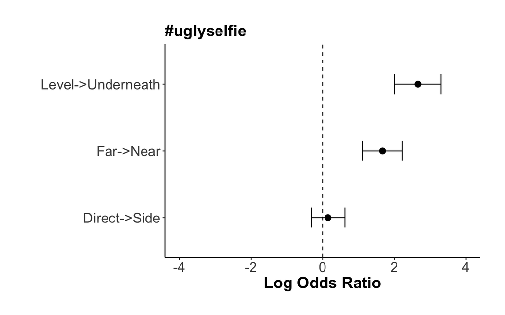

```r
# Extract the relevant coefficients and 95% credible intervals:
ugly_coefs <- as.data.frame(fixef(ugly.brm)[-(1:4), ])
boring_coefs <- as.data.frame(fixef(boring.brm)[-(1:4), ])
serious_coefs <- as.data.frame(fixef(serious.brm)[-(1:4), ])
ironic_coefs <- as.data.frame(fixef(ironic.brm)[-(1:4), ])
funny_coefs <- as.data.frame(fixef(funny.brm)[-(1:4), ])

# Name the rows transparently:

effect_order <- c('Level->Underneath',
                  'Far->Near', 'Direct->Side',
                  'Female->Male')
effect_order <- factor(effect_order,
                       levels = rev(effect_order))

boring_coefs$Effect <- effect_order
funny_coefs$Effect <- effect_order
serious_coefs$Effect <- effect_order
ironic_coefs$Effect <- effect_order
ugly_coefs$Effect <- effect_order

# Plot the coefficients:
ugly.p <- ugly_coefs[-4, ] %>% ggplot(aes(y = Estimate, x = Effect)) +
  geom_point(size = 3) + geom_errorbar(aes(ymin = Q2.5, ymax = Q97.5), width = 0.3) + ylim(-4, 4) + coord_flip() + geom_hline(aes(yintercept = 0), linetype = 2) + theme_timo + ylab('Log Odds Ratio') + xlab('') + ggtitle('#uglyselfie')
ugly.p
```

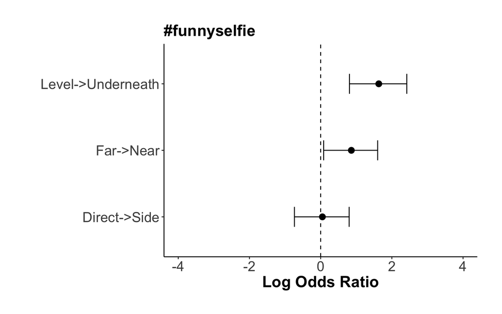

```r
funny.p <- funny_coefs[-4, ] %>% ggplot(aes(y = Estimate, x = Effect)) +
  geom_point(size = 3) + geom_errorbar(aes(ymin = Q2.5, ymax = Q97.5), width = 0.3) + ylim(-4, 4) + coord_flip() + geom_hline(aes(yintercept = 0), linetype = 2) + theme_timo + ylab('Log Odds Ratio') + xlab('') + ggtitle('#funnyselfie')
funny.p
```

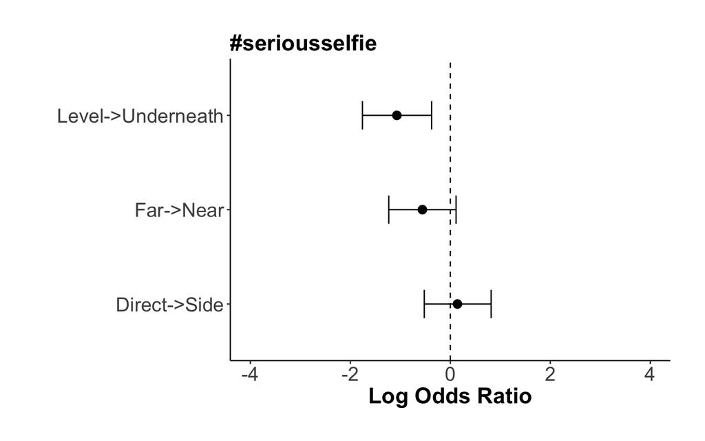

```r
serious.p <- serious_coefs[-4, ] %>% ggplot(aes(y = Estimate, x = Effect)) +
  geom_point(size = 3) + geom_errorbar(aes(ymin = Q2.5, ymax = Q97.5), width = 0.3) + ylim(-4, 4) + coord_flip() + geom_hline(aes(yintercept = 0), linetype = 2) + theme_timo + ylab('Log Odds Ratio') + xlab('') + ggtitle('#seriousselfie')
serious.p
```

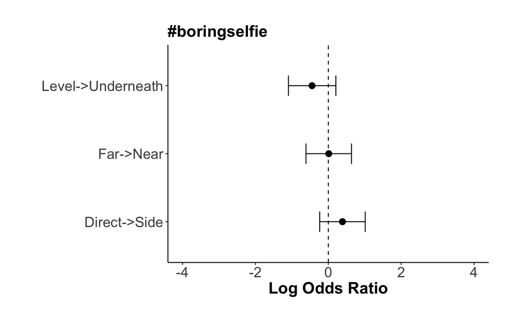

```r
boring.p <- boring_coefs[-4, ] %>% ggplot(aes(y = Estimate, x = Effect)) +
  geom_point(size = 3) + geom_errorbar(aes(ymin = Q2.5, ymax = Q97.5), width = 0.3) + ylim(-4, 4) + coord_flip() + geom_hline(aes(yintercept = 0), linetype = 2) + theme_timo + ylab('Log Odds Ratio') + xlab('') + ggtitle('#boringselfie')
boring.p
```

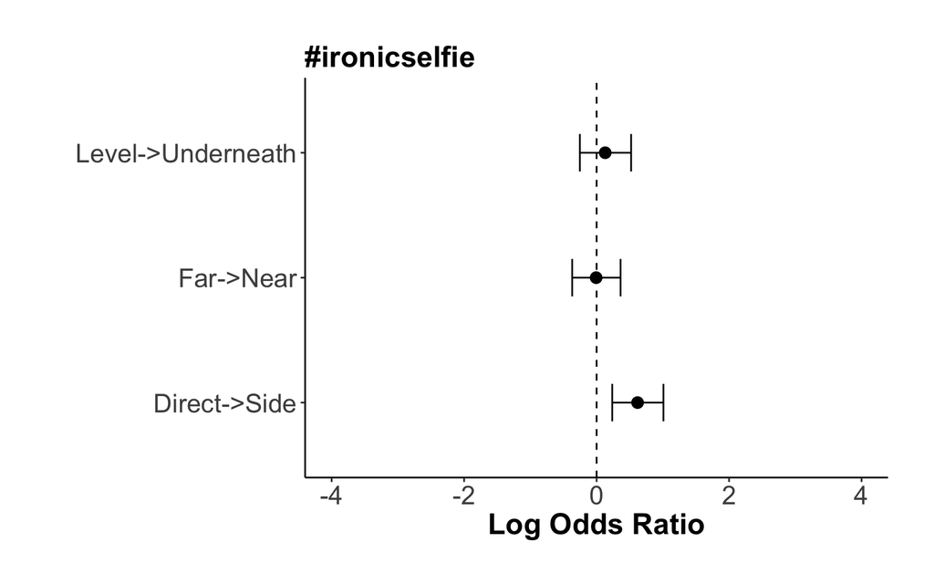

```r
ironic.p <- ironic_coefs[-4, ] %>% ggplot(aes(y = Estimate, x = Effect)) +
  geom_point(size = 3) + geom_errorbar(aes(ymin = Q2.5, ymax = Q97.5), width = 0.3) + ylim(-4, 4) + coord_flip() + geom_hline(aes(yintercept = 0), linetype = 2) + theme_timo + ylab('Log Odds Ratio') + xlab('') + ggtitle('#ironicselfie')
ironic.p
```

Make plots of them together:

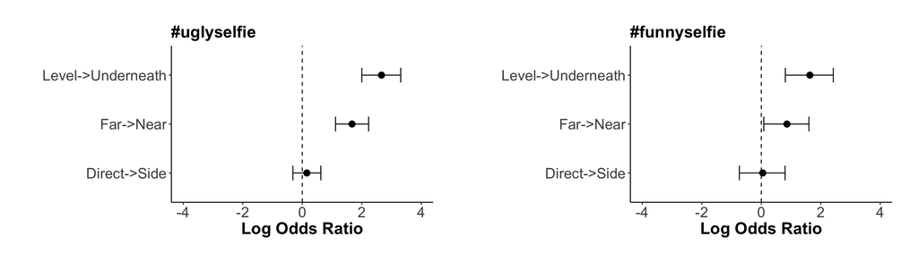

```r
# Make a plot with all of them together:
grid.arrange(ugly.p, funny.p, nrow = 1)#1,200 vs. 400
```

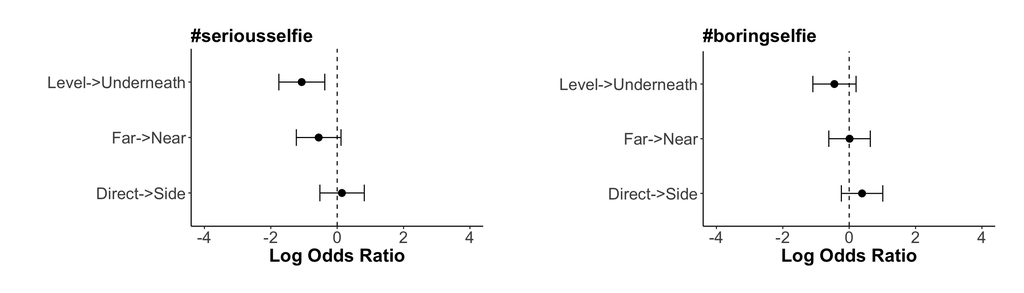

```r
grid.arrange(serious.p, boring.p, nrow = 1)
```

## Analysis 3: Individual differences

For now, I will only do this analysis with the best-performing model (ugly selfies).

Let’s extract the random effects estimates:

```r
ugly.coefs <- coef(ugly.brm)
ugly_REs <- cbind(ugly.coefs$ResponseId[, , "TiltTilted"][, 1],
  ugly.coefs$ResponseId[, , "DistanceNear"][, 1],
  ugly.coefs$ResponseId[, , "EyesSide"][, 1],
  ugly.coefs$ResponseId[, , "StimGenderMale"][, 1])
ugly_REs <- as.data.frame(ugly_REs)
colnames(ugly_REs) <- c('CameraAngle', 'Distance', 'EyeSight', 'Person')

# Add ResponseID column:

ugly_REs$Participant <- rownames(ugly_REs)

# Add age info:

ugly_REs <- bind_cols(ugly_REs,
          self[match(ugly_REs$Participant, self$ResponseId), c('Age', 'Selfietaking')])

# check:
head(ugly_REs)
```

```
##   CameraAngle   Distance  EyeSight     Person       Participant Age
## 1 -0.06824164  0.8225706 0.1392240 -0.3797639 R_00OlMTXsIar3zHj  34
## 2  5.45139599  2.0501998 0.1832456  1.2104303 R_0IJR3pgtfcdxe2B  19
## 3 -0.33231559 -0.2458707 0.1443181  1.1629434 R_10BoO25kkjsfeLo  43
## 4 11.53755814  5.0432431 0.2519567  3.8742750 R_123YVnrORavW4At  39
## 5  3.49534917  2.4083753 0.1494529  0.1723282 R_12M70a3TN80PMDU  31
## 6  5.77649401  2.1184982 0.1764188 -0.1490793 R_1C3aEpbLrFrYrFm  34
##            Selfietaking
## 1 Less than once a week
## 2 Less than once a week
## 3  Several times a week
## 4 Less than once a week
## 5           Once a week
## 6 Less than once a week
```

Make plots of the random effects and explore their statistics.

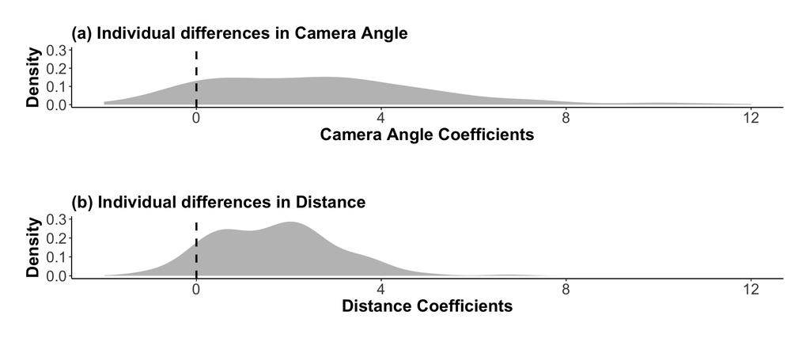

```r
# Make histograms of these:

camera.hist <- ggplot(ugly_REs, aes(x = CameraAngle)) +
  geom_density(fill = rgb(0, 0, 0, 0.3),
               colour = rgb(0, 0, 0, 0)) + theme_timo +
  xlim(-2, 12) + ylim(0, 0.3) +
  xlab('Camera Angle Coefficients') +
  ylab('Density') +
  geom_vline(aes(xintercept = 0), linetype = 2, size = 1) +
  ggtitle('(a) Individual differences in Camera Angle')

distance.hist <- ggplot(ugly_REs, aes(x = Distance)) +
  geom_density(fill = rgb(0, 0, 0, 0.3),
               colour = rgb(0, 0, 0, 0)) +
  xlim(-2, 12) + ylim(0, 0.3) +
  xlab('Distance Coefficients') +
  ylab('Density') +
  geom_vline(aes(xintercept = 0), linetype = 2, size = 1) +
  ggtitle('(b) Individual differences in Distance') +
  theme_timo

grid.arrange(camera.hist, distance.hist, nrow = 2)
```

```r
# Report statistics:

range(ugly_REs$CameraAngle)
```

```
## [1] -1.900651 11.537558
```

```r
range(ugly_REs$Distance)
```

```
## [1] -1.283236  6.735277
```

```r
range(ugly_REs$EyeSight)
```

```
## [1] 0.05036013 0.25195666
```

Check correlations between the random effects estimates (to what extent is a participant’s response in one condition affected by response to another?). This is also apparent in the brms output above. Here, I additionally perform a PCA on the random slopes to further explore the structure of the individual differences.

```r
# Check correlations:

round(cor(select(ugly_REs, CameraAngle:Person)), 2)
```

```
##             CameraAngle Distance EyeSight Person
## CameraAngle        1.00     0.82     0.61   0.22
## Distance           0.82     1.00     0.79   0.12
## EyeSight           0.61     0.79     1.00   0.41
## Person             0.22     0.12     0.41   1.00
```

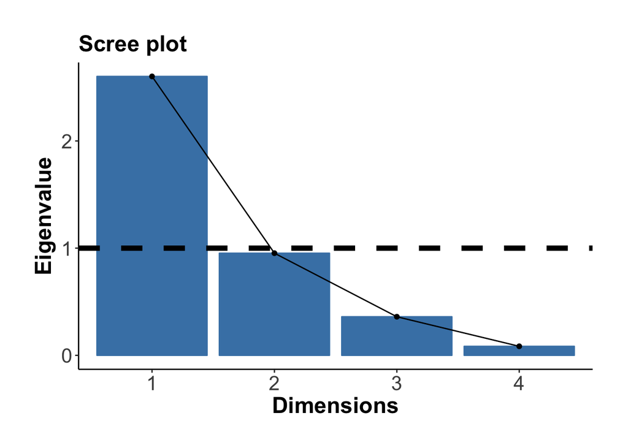

```r
# Perform Principal Components Analysis on random effects:

ugly_RE_pca <- prcomp(select(ugly_REs, CameraAngle:Person),
                      center = TRUE, scale = TRUE)

# Scree plot for looking at how many components are supported by the data:

fviz_screeplot(ugly_RE_pca, choice = 'eigenvalue') +
  geom_hline(yintercept = 1.0, linetype = 2, size = 2) + theme_timo
```

```r
# Check loadings:

round(ugly_RE_pca$rotation, 2)
```

```
##              PC1   PC2   PC3   PC4
## CameraAngle 0.54  0.22  0.70  0.41
## Distance    0.57  0.32 -0.11 -0.75
## EyeSight    0.56 -0.10 -0.67  0.48
## Person      0.26 -0.92  0.21 -0.22
```

The PCA suggests that there’s only one axis of variation in the random effects component. This variation seems to be dominated by how much participants respond to the three main condition variables overall, i.e., strong versus weak responders (perhaps this is due to paying attention to the task, or it is actually phenomenal).

```r
round(cor(select(ugly_REs, CameraAngle:Person, Age)), 2)
```

```
##             CameraAngle Distance EyeSight Person   Age
## CameraAngle        1.00     0.82     0.61   0.22 -0.20
## Distance           0.82     1.00     0.79   0.12 -0.09
## EyeSight           0.61     0.79     1.00   0.41 -0.07
## Person             0.22     0.12     0.41   1.00 -0.16
## Age               -0.20    -0.09    -0.07  -0.16  1.00
```

```r
with(ugly_REs, cor.test(CameraAngle, Age))
```

```
##
##  Pearson's product-moment correlation
##
## data:  CameraAngle and Age
## t = -2.2992, df = 133, p-value = 0.02305
## alternative hypothesis: true correlation is not equal to 0
## 95 percent confidence interval:
##  -0.35282290 -0.02747152
## sample estimates:
##        cor
## -0.1955211
```

```r
with(ugly_REs, cor.test(Distance, Age))
```

```
##
##  Pearson's product-moment correlation
##
## data:  Distance and Age
## t = -1.0367, df = 133, p-value = 0.3017
## alternative hypothesis: true correlation is not equal to 0
## 95 percent confidence interval:
##  -0.25463916  0.08064302
## sample estimates:
##         cor
## -0.08953405
```

```r
with(ugly_REs, cor.test(EyeSight, Age))
```

```
##
##  Pearson's product-moment correlation
##
## data:  EyeSight and Age
## t = -0.84267, df = 133, p-value = 0.4009
## alternative hypothesis: true correlation is not equal to 0
## 95 percent confidence interval:
##  -0.23889057  0.09728011
## sample estimates:
##         cor
## -0.07287482
```

```r
with(ugly_REs, cor.test(Person, Age))
```

```
##
##  Pearson's product-moment correlation
##
## data:  Person and Age
## t = -1.9128, df = 133, p-value = 0.05792
## alternative hypothesis: true correlation is not equal to 0
## 95 percent confidence interval:
##  -0.323637315  0.005481222
## sample estimates:
##        cor
## -0.1636275
```

Make a plot of the correlation with age:

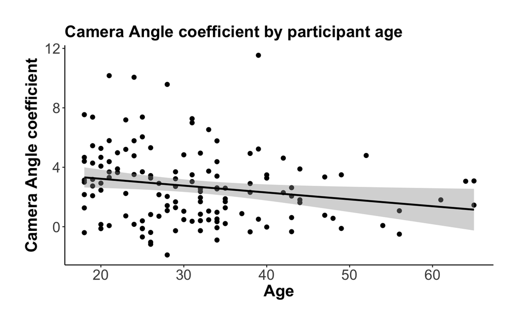

```r
ggplot(ugly_REs, aes(x = Age, y = CameraAngle)) +
  geom_point(size = 2) +
  geom_smooth(method = 'lm', color = 'black') +
  theme_timo +
  ggtitle('Camera Angle coefficient by participant age') + ylab('Camera Angle coefficient')
```

Let’s look at selfie-taking behavior:

```r
# Check overall selfie-taking behavior:
table(ugly_REs$Selfietaking)
```

```
##
##   At least once a day Less than once a week           Once a week
##                     9                    77                    21
##  Several times a week
##                    28
```

```r
round(prop.table(table(ugly_REs$Selfietaking)), 2)
```

```
##
##   At least once a day Less than once a week           Once a week
##                  0.07                  0.57                  0.16
##  Several times a week
##                  0.21
```

```r
# First as a simple factor:
anova(lm(CameraAngle ~ Selfietaking, data = ugly_REs))
```

```
## Analysis of Variance Table
##
## Response: CameraAngle
##               Df Sum Sq Mean Sq F value Pr(>F)
## Selfietaking   3  30.82  10.275  1.6601 0.1788
## Residuals    131 810.76   6.189
```

```r
anova(lm(Distance ~ Selfietaking, data = ugly_REs))
```

```
## Analysis of Variance Table
##
## Response: Distance
##               Df  Sum Sq Mean Sq F value Pr(>F)
## Selfietaking   3   1.573 0.52417  0.2908  0.832
## Residuals    131 236.164 1.80278
```

```r
anova(lm(EyeSight ~ Selfietaking, data = ugly_REs))
```

```
## Analysis of Variance Table
##
## Response: EyeSight
##               Df   Sum Sq   Mean Sq F value  Pr(>F)
## Selfietaking   3 0.017733 0.0059109  2.9555 0.03492 *
## Residuals    131 0.261991 0.0019999
## ---
## Signif. codes:  0 '***' 0.001 '**' 0.01 '*' 0.05 '.' 0.1 ' ' 1
```

```r
# R-squared:
summary(lm(CameraAngle ~ Selfietaking, data = ugly_REs))$r.squared
```

```
## [1] 0.03662587
```

```r
summary(lm(Distance ~ Selfietaking, data = ugly_REs))$r.squared
```

```
## [1] 0.00661446
```

```r
summary(lm(EyeSight ~ Selfietaking, data = ugly_REs))$r.squared
```

```
## [1] 0.06339354
```

```r
# Then numerical coding:
ugly_REs <- mutate(ugly_REs,
                   Selfietaking_numeric = ifelse(Selfietaking == 'Less than once a week', 0, Selfietaking),
                   Selfietaking_numeric = ifelse(Selfietaking_numeric == 'Once a week', 1, Selfietaking_numeric),
                   Selfietaking_numeric = ifelse(Selfietaking_numeric == 'Several times a week', 2, Selfietaking_numeric),
                   Selfietaking_numeric = ifelse(Selfietaking_numeric == 'At least once a day', 3, Selfietaking_numeric),
                   Selfietaking_numeric = as.numeric(Selfietaking_numeric))
# Then models:
summary(lm(CameraAngle ~ Selfietaking_numeric, data = ugly_REs))
```

```
##
## Call:
## lm(formula = CameraAngle ~ Selfietaking_numeric, data = ugly_REs)
##
## Residuals:
##     Min      1Q  Median      3Q     Max
## -4.8724 -1.8927 -0.2536  1.5632  8.5658
##
## Coefficients:
##                      Estimate Std. Error t value Pr(>|t|)
## (Intercept)            2.9718     0.2711  10.964   <2e-16 ***
## Selfietaking_numeric  -0.3489     0.2153  -1.621    0.107
## ---
## Signif. codes:  0 '***' 0.001 '**' 0.01 '*' 0.05 '.' 0.1 ' ' 1
##
## Residual standard error: 2.491 on 133 degrees of freedom
## Multiple R-squared:  0.01937,    Adjusted R-squared:  0.01199
## F-statistic: 2.627 on 1 and 133 DF,  p-value: 0.1074
```

```r
summary(lm(Distance ~ Selfietaking_numeric, data = ugly_REs))
```

```
##
## Call:
## lm(formula = Distance ~ Selfietaking_numeric, data = ugly_REs)
##
## Residuals:
##     Min      1Q  Median      3Q     Max
## -3.0278 -1.0303  0.0656  0.8317  5.1241
##
## Coefficients:
##                      Estimate Std. Error t value Pr(>|t|)
## (Intercept)           1.74458    0.14530  12.007   <2e-16 ***
## Selfietaking_numeric -0.06673    0.11540  -0.578    0.564
## ---
## Signif. codes:  0 '***' 0.001 '**' 0.01 '*' 0.05 '.' 0.1 ' ' 1
##
## Residual standard error: 1.335 on 133 degrees of freedom
## Multiple R-squared:  0.002507,   Adjusted R-squared:  -0.004993
## F-statistic: 0.3343 on 1 and 133 DF,  p-value: 0.5641
```

```r
summary(lm(EyeSight ~ Selfietaking_numeric, data = ugly_REs))
```

```
##
## Call:
## lm(formula = EyeSight ~ Selfietaking_numeric, data = ugly_REs)
##
## Residuals:
##       Min        1Q    Median        3Q       Max
## -0.111034 -0.032015 -0.002168  0.028549  0.092736
##
## Coefficients:
##                       Estimate Std. Error t value Pr(>|t|)
## (Intercept)           0.161395   0.004875  33.108   <2e-16 ***
## Selfietaking_numeric -0.009774   0.003872  -2.524   0.0128 *
## ---
## Signif. codes:  0 '***' 0.001 '**' 0.01 '*' 0.05 '.' 0.1 ' ' 1
##
## Residual standard error: 0.0448 on 133 degrees of freedom
## Multiple R-squared:  0.04572,    Adjusted R-squared:  0.03855
## F-statistic: 6.372 on 1 and 133 DF,  p-value: 0.01277
```

Extract principal components scores (PC1) and correlate them with age and selfie-taking:

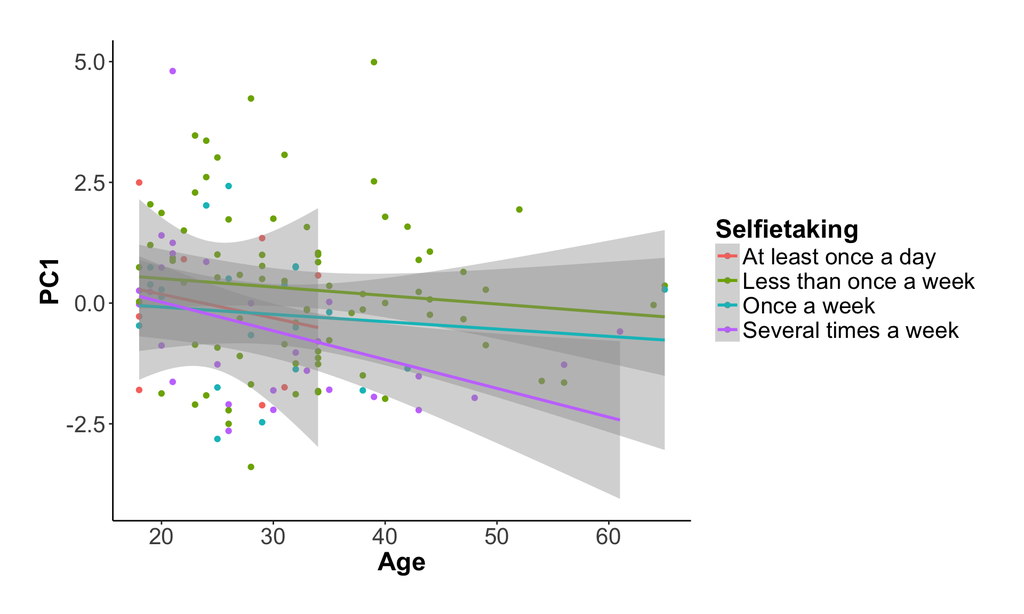

```r
ugly_REs$PC1 <- ugly_RE_pca$x[, 1]
# PC1 by age:
ugly_REs %>% ggplot(aes(x = Age, y = PC1, col = Selfietaking)) +
  geom_point() + geom_smooth(method = 'lm') + theme_timo
```

```r
# Check correlation:
with(ugly_REs, cor.test(Age, PC1))
```

```
##
##  Pearson's product-moment correlation
##
## data:  Age and PC1
## t = -1.7393, df = 133, p-value = 0.08429
## alternative hypothesis: true correlation is not equal to 0
## 95 percent confidence interval:
##  -0.31027132  0.02033752
## sample estimates:
##        cor
## -0.1491321
```

Check effect of selfie-taking on PC1.

```r
# Check by-selfie:
ugly_REs %>%
  group_by(Selfietaking) %>%
  summarize(PC1_M = mean(PC1, na.rm = TRUE))
```

```
## # A tibble: 4 x 2
##   Selfietaking            PC1_M
##   <chr>                   <dbl>
## 1 At least once a day   -0.0255
## 2 Less than once a week  0.279
## 3 Once a week           -0.225
## 4 Several times a week  -0.589
```

```r
anova(lm(PC1 ~ Selfietaking, data = ugly_REs))
```

```
## Analysis of Variance Table
##
## Response: PC1
##               Df Sum Sq Mean Sq F value  Pr(>F)
## Selfietaking   3  16.77  5.5895  2.2061 0.09041 .
## Residuals    131 331.90  2.5336
## ---
## Signif. codes:  0 '***' 0.001 '**' 0.01 '*' 0.05 '.' 0.1 ' ' 1
```

## Analysis 4: Descriptive means

Let’s plot some descriptive means for ugly.

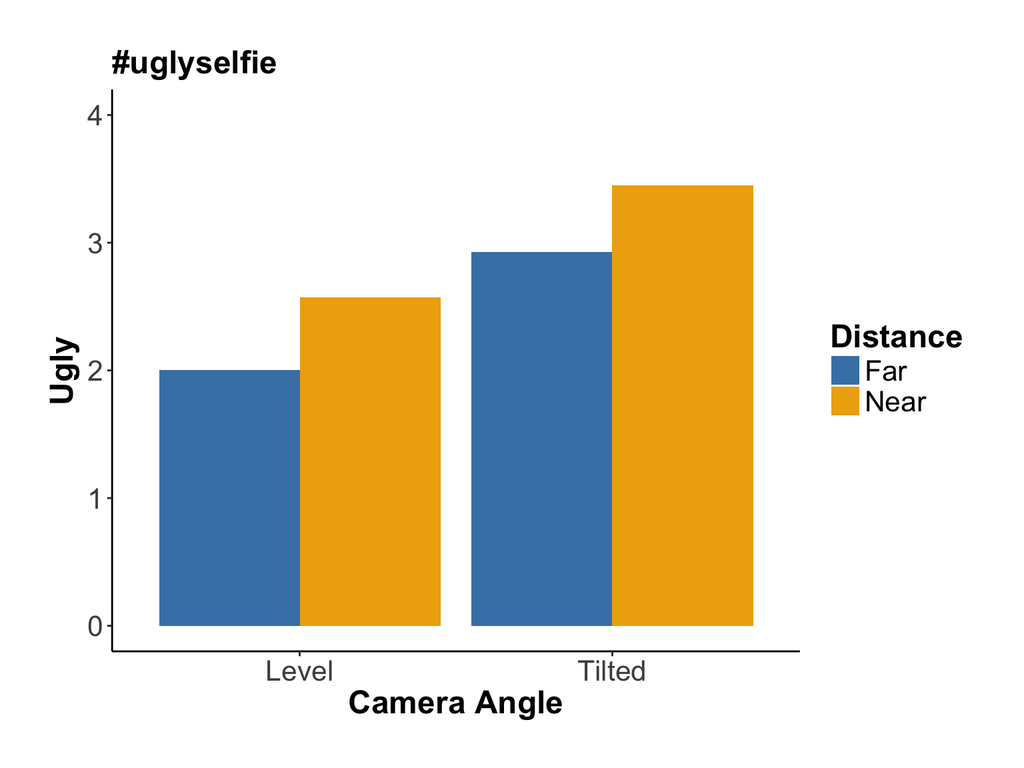

```r
self %>% group_by(Distance, Tilt) %>%
  summarize(Ugly = mean(Ugly, na.rm = TRUE)) %>%
  ggplot(aes(x = Tilt, y = Ugly, fill = Distance)) +
  geom_bar(stat = 'identity', position = 'dodge') + theme_timo +
  ylim(0, 4) + scale_fill_manual(values = c('steelblue', 'darkgoldenrod2')) + ggtitle('#uglyselfie') + xlab('Camera Angle')
```

Same for funny.

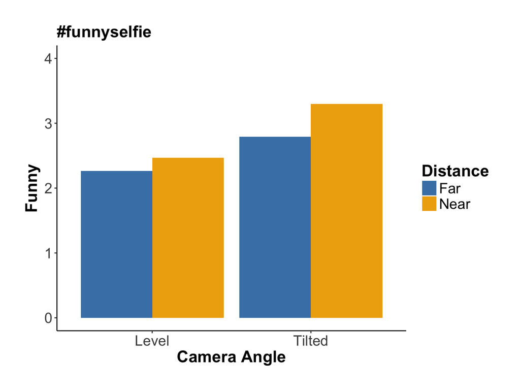

```r
self %>% group_by(Distance, Tilt) %>%
  summarize(Funny = mean(Funny, na.rm = TRUE)) %>%
  ggplot(aes(x = Tilt, y = Funny, fill = Distance)) +
  geom_bar(stat = 'identity', position = 'dodge') + theme_timo +
  ylim(0, 4) + scale_fill_manual(values = c('steelblue', 'darkgoldenrod2')) + ggtitle('#funnyselfie') + xlab('Camera Angle')
```

Same for serious selfie.

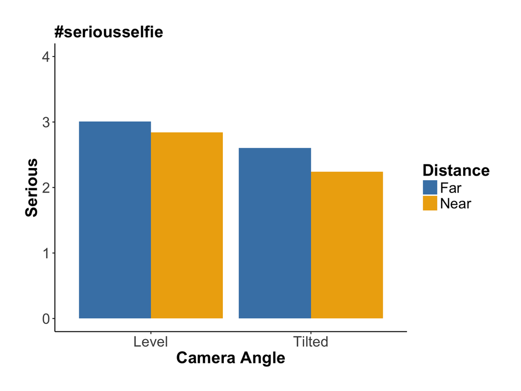

```r
self %>% group_by(Distance, Tilt) %>%
  summarize(Serious = mean(Serious, na.rm = TRUE)) %>%
  ggplot(aes(x = Tilt, y = Serious, fill = Distance)) +
  geom_bar(stat = 'identity', position = 'dodge') + theme_timo +
  ylim(0, 4) + scale_fill_manual(values = c('steelblue', 'darkgoldenrod2')) + ggtitle('#seriousselfie') + xlab('Camera Angle')
```

Same for boring.

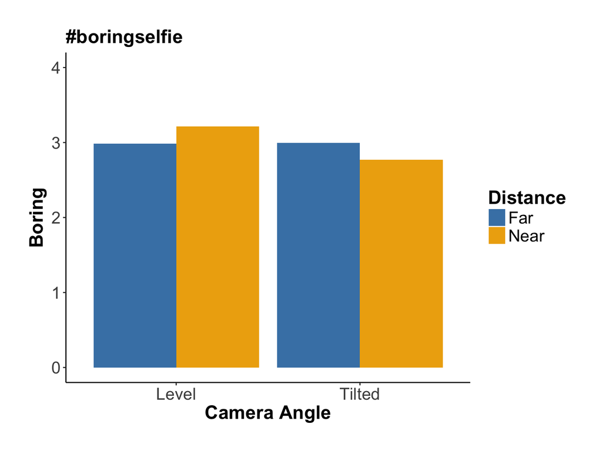

```r
self %>% group_by(Distance, Tilt) %>%
  summarize(Boring = mean(Boring, na.rm = TRUE)) %>%
  ggplot(aes(x = Tilt, y = Boring, fill = Distance)) +
  geom_bar(stat = 'identity', position = 'dodge') + theme_timo +
  ylim(0, 4) + scale_fill_manual(values = c('steelblue', 'darkgoldenrod2')) + ggtitle('#boringselfie') + xlab('Camera Angle')
```

Same for ironic.

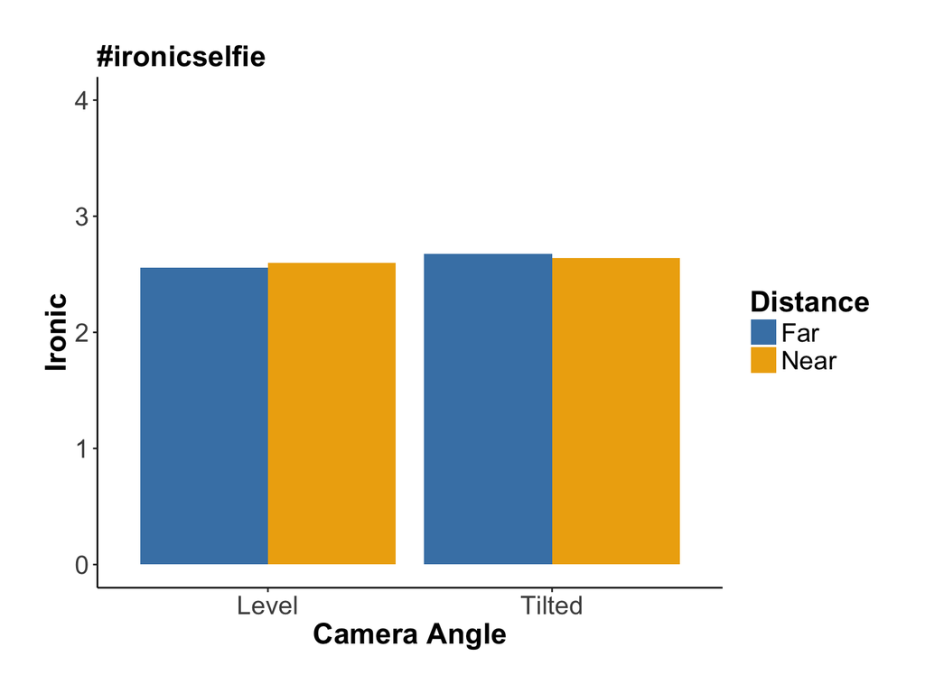

```r
self %>% group_by(Distance, Tilt) %>%
  summarize(Ironic = mean(Ironic, na.rm = TRUE)) %>%
  ggplot(aes(x = Tilt, y = Ironic, fill = Distance)) +
  geom_bar(stat = 'identity', position = 'dodge') + theme_timo +
  ylim(0, 4) + scale_fill_manual(values = c('steelblue', 'darkgoldenrod2')) + ggtitle('#ironicselfie') + xlab('Camera Angle')
```

Eyes and ironic:

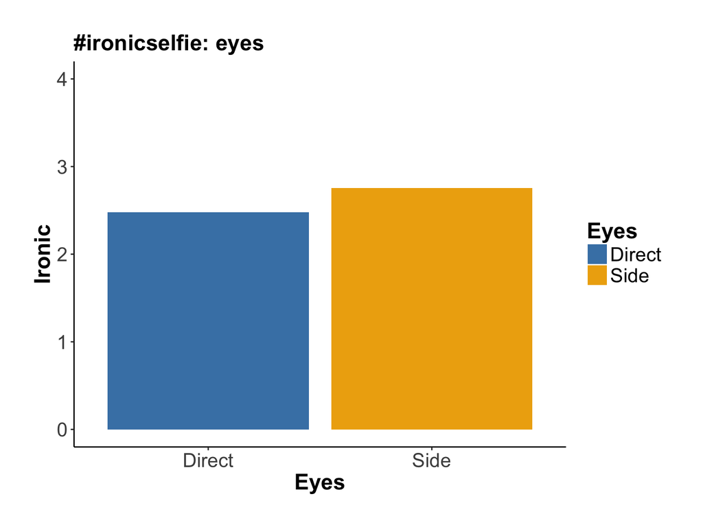

```r
self %>% group_by(Eyes) %>%
  summarize(Ironic = mean(Ironic, na.rm = TRUE)) %>%
  ggplot(aes(x = Eyes, y = Ironic, fill = Eyes)) +
  geom_bar(stat = 'identity', position = 'dodge') + theme_timo +
  ylim(0, 4) + scale_fill_manual(values = c('steelblue', 'darkgoldenrod2')) + ggtitle('#ironicselfie: eyes') + xlab('Eyes')
```

Descriptive means:

```r
self %>% group_by(Tilt) %>%
  summarize(Ugly = round(mean(Ugly, na.rm = TRUE), 2),
            Funny = round(mean(Funny, na.rm = TRUE), 2),
            Serious = round(mean(Serious, na.rm = TRUE), 2),
            Boring = round(mean(Funny, na.rm = TRUE), 2),
            Ironic = round(mean(Ironic, na.rm = TRUE), 2))
```

```
## # A tibble: 2 x 6
##   Tilt    Ugly Funny Serious Boring Ironic
##   <chr>  <dbl> <dbl>   <dbl>  <dbl>  <dbl>
## 1 Level   2.29  2.37    2.92   2.37   2.58
## 2 Tilted  3.19  3.04    2.42   3.04   2.66
```

```r
self %>% group_by(Distance) %>%
  summarize(Ugly = round(mean(Ugly, na.rm = TRUE), 2),
            Funny = round(mean(Funny, na.rm = TRUE), 2),
            Serious = round(mean(Serious, na.rm = TRUE), 2),
            Boring = round(mean(Funny, na.rm = TRUE), 2),
            Ironic = round(mean(Ironic, na.rm = TRUE), 2))
```

```
## # A tibble: 2 x 6
##   Distance  Ugly Funny Serious Boring Ironic
##   <chr>    <dbl> <dbl>   <dbl>  <dbl>  <dbl>
## 1 Far       2.46  2.53    2.8    2.53   2.62
## 2 Near      3.01  2.88    2.54   2.88   2.62
```

```r
self %>% group_by(Eyes) %>%
  summarize(Ugly = round(mean(Ugly, na.rm = TRUE), 2),
            Funny = round(mean(Funny, na.rm = TRUE), 2),
            Serious = round(mean(Serious, na.rm = TRUE), 2),
            Boring = round(mean(Funny, na.rm = TRUE), 2),
            Ironic = round(mean(Ironic, na.rm = TRUE), 2))
```

```
## # A tibble: 2 x 6
##   Eyes    Ugly Funny Serious Boring Ironic
##   <chr>  <dbl> <dbl>   <dbl>  <dbl>  <dbl>
## 1 Direct  2.71  2.69    2.64   2.69   2.48
## 2 Side    2.77  2.72    2.7    2.72   2.75
```